# Problem Set 3

Author

Owen Brooks

Published

October 25, 2026

```r
library(tidyverse)
library(fpp3)
```

## Time and Tsibbles

**The two datasets.**

### 2.2 Reading the data

```r
retail_raw <- read_csv("data/retail_sales_raw.csv")
head(retail_raw)
```

```
# A tibble: 6 × 3
  observation_date  RSAFS RSAFSNA
  <date>            <dbl>   <dbl>
1 1992-01-01       159177  142051
2 1992-02-01       159189  142498
3 1992-03-01       158647  154439
4 1992-04-01       159921  158430
5 1992-05-01       160471  164788
6 1992-06-01       161205  163417
```

```r
retail_raw <- read_csv(
  "data/retail_sales_raw.csv",
  na = ".",
  col_types = cols(
    observation_date = col_date(format = "%Y-%m-%d"),
    RSAFS = col_double(),
    RSAFSNA = col_double()
  )
)
```

### 2.3–2.4 Long format and the tsibble

```r
retail_raw_long <- retail_raw |>
  select(observation_date, RSAFS, RSAFSNA) |>
  pivot_longer(cols = c(RSAFS, RSAFSNA), names_to = "series_id", values_to = "sales")

head(retail_raw_long)
```

```
# A tibble: 6 × 3
  observation_date series_id  sales
  <date>           <chr>      <dbl>
1 1992-01-01       RSAFS     159177
2 1992-01-01       RSAFSNA   142051
3 1992-02-01       RSAFS     159189
4 1992-02-01       RSAFSNA   142498
5 1992-03-01       RSAFS     158647
6 1992-03-01       RSAFSNA   154439
```

```r
retail_ts <- retail_raw_long |>
  mutate(Month = yearmonth(observation_date)) |>
  as_tsibble(index = Month, key = series_id)

head(retail_ts)
```

```
# A tsibble: 6 x 4 [1M]
# Key:       series_id [1]
  observation_date series_id  sales    Month
  <date>           <chr>      <dbl>    <mth>
1 1992-01-01       RSAFS     159177 1992 Jan
2 1992-02-01       RSAFS     159189 1992 Feb
3 1992-03-01       RSAFS     158647 1992 Mar
4 1992-04-01       RSAFS     159921 1992 Apr
5 1992-05-01       RSAFS     160471 1992 May
6 1992-06-01       RSAFS     161205 1992 Jun
```

```r
has_gaps(retail_ts)
```

```
# A tibble: 2 × 2
  series_id .gaps
  <chr>     <lgl>
1 RSAFS     FALSE
2 RSAFSNA   FALSE
```

### 2.5 Canadian gas production

```r
key_vars(canadian_gas)
```

```
character(0)
```

```r
index_var(canadian_gas)
```

```
[1] "Month"
```

```r
can_gas <- canadian_gas |>
  select(Month, Volume)

has_gaps(can_gas)
```

```
# A tibble: 1 × 1
  .gaps
  <lgl>
1 FALSE
```

```r
head(can_gas)
```

```
# A tsibble: 6 x 2 [1M]
     Month Volume
     <mth>  <dbl>
1 1960 Jan   1.43
2 1960 Feb   1.31
3 1960 Mar   1.40
4 1960 Apr   1.17
5 1960 May   1.12
6 1960 Jun   1.01
```

### 2.6 Working with dates

```r
can_gas_recent <- can_gas |>
  filter(Month >= yearmonth("1990 Jan")) |>
  mutate(year = year(Month),
         month = month(Month, label = TRUE),
         quarter = quarter(Month))

can_gas_recent |>
  as_tibble() |>
  group_by(month) |>
  summarize(avg_volume = mean(Volume)) |>
  knitr::kable(digits = 2)
```

| month | avg_volume |
| --- | --- |
| Jan | 16.99 |
| Feb | 15.28 |
| Mar | 16.34 |
| Apr | 15.74 |
| May | 15.75 |
| Jun | 14.94 |
| Jul | 15.60 |
| Aug | 15.62 |
| Sep | 15.13 |
| Oct | 16.16 |
| Nov | 16.18 |
| Dec | 17.15 |

December has the highest average production of 17.1 and June has the lowest with 14.9 indicating that production peaks in the winter.

```r
can_gas_recent |>
  mutate(next_month = Month + 1,
         same_month_last_year = Month - 12) |>
  head()
```

```
# A tsibble: 6 x 7 [1M]
     Month Volume  year month quarter next_month same_month_last_year
     <mth>  <dbl> <dbl> <ord>   <int>      <mth>                <mth>
1 1990 Jan   12.5  1990 Jan         1   1990 Feb             1989 Jan
2 1990 Feb   11.2  1990 Feb         1   1990 Mar             1989 Feb
3 1990 Mar   11.6  1990 Mar         1   1990 Apr             1989 Mar
4 1990 Apr   11.1  1990 Apr         2   1990 May             1989 Apr
5 1990 May   11.0  1990 May         2   1990 Jun             1989 May
6 1990 Jun   10.1  1990 Jun         2   1990 Jul             1989 Jun
```

```r
can_gas_q <- can_gas |>
  filter(Month <= yearmonth("2004 Dec")) |>
  index_by(Quarter = yearquarter(Month)) |>
  summarize(Volume = sum(Volume))

head(can_gas_q)
```

```
# A tsibble: 6 x 2 [1Q]
  Quarter Volume
    <qtr>  <dbl>
1 1960 Q1   4.14
2 1960 Q2   3.30
3 1960 Q3   2.97
4 1960 Q4   4.26
5 1961 Q1   5.01
6 1961 Q2   4.17
```

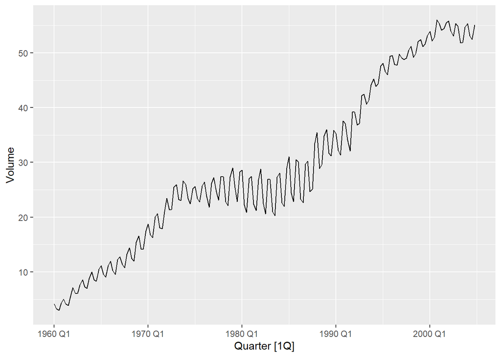

```r
can_gas_q |> autoplot(Volume)
```

Gas production is a flow meaning each month’s value is the amount actually produced in that month. A quarter’s production is the sum of three months of flow and an average would not be at all helpful.

### 2.7 Plotting

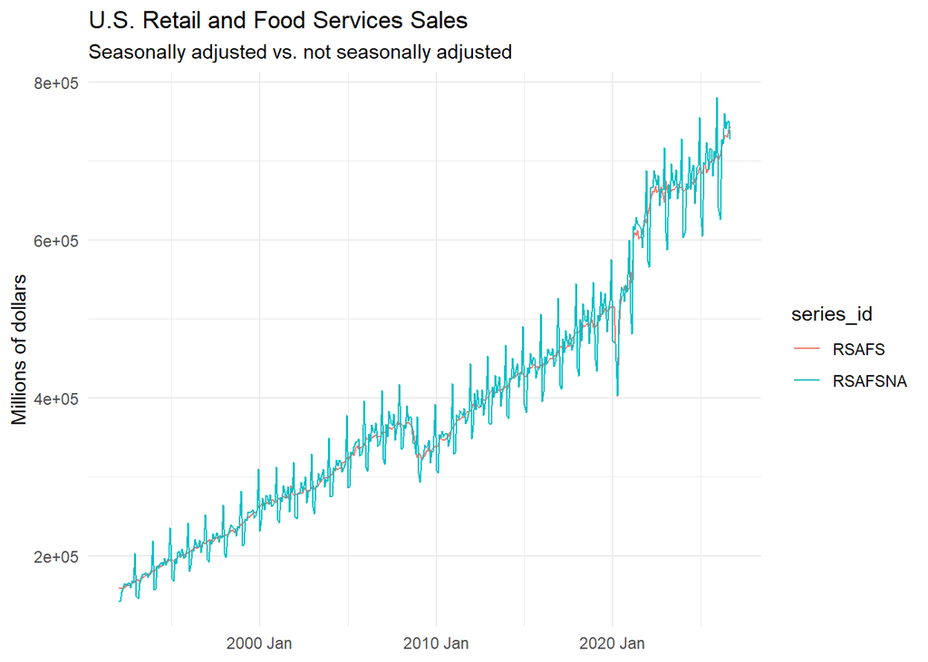

```r
retail_ts |>
  autoplot(sales) +
  labs(
    title = "U.S. Retail and Food Services Sales",
    subtitle = "Seasonally adjusted vs. not seasonally adjusted",
    x = NULL, y = "Millions of dollars", color = NULL
  ) +
  theme_minimal()
```

The NSA series has a yearly seasonal pattern with sales spiking in the holiday season and dropping in February. SA series doesn’t have them since it has been seasonally adjusted but both share long run trajectory.

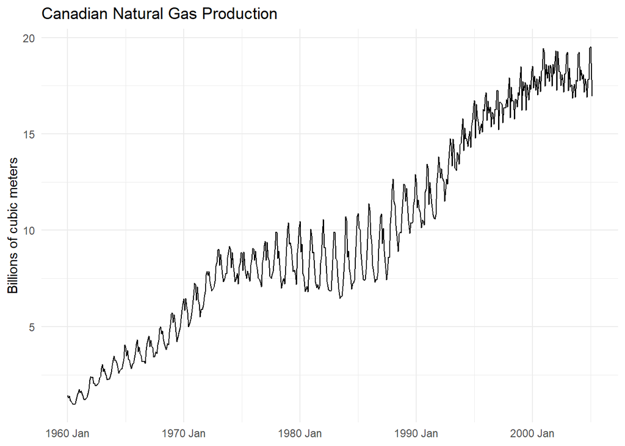

```r
can_gas |>
  autoplot(Volume) +
  labs(
    title = "Canadian Natural Gas Production",
    x = NULL, y = "Billions of cubic meters"
  ) +
  theme_minimal()
```

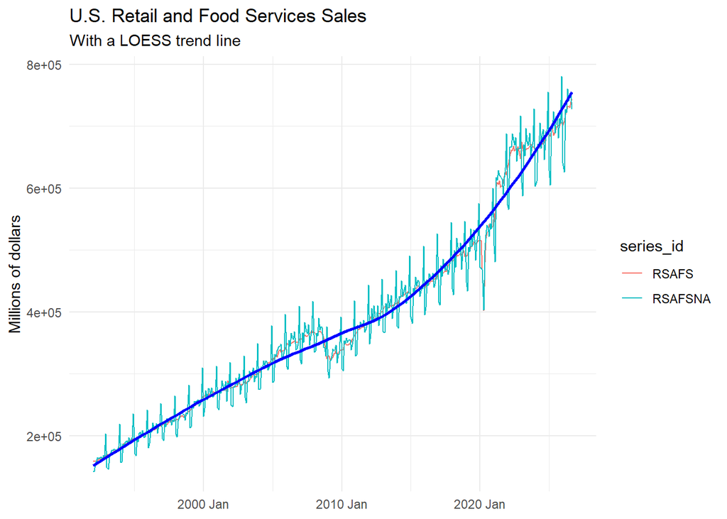

```r
retail_ts |>
  autoplot(sales) +
  geom_smooth(method = "loess", se = FALSE, color = "blue") +
  labs(
    title = "U.S. Retail and Food Services Sales",
    subtitle = "With a LOESS trend line",
    x = NULL, y = "Millions of dollars", color = NULL
  ) +
  theme_minimal()
```

I added a geom_smooth() line on top of the series just to show the long run trend of steady growth without the seasonal noise.

## Transformations

### 3.1 Log transformation

The swings in can_gas are growing with the level from the 60s on. Later on they stop growing and/or shrink later in the 90s and 2000s.

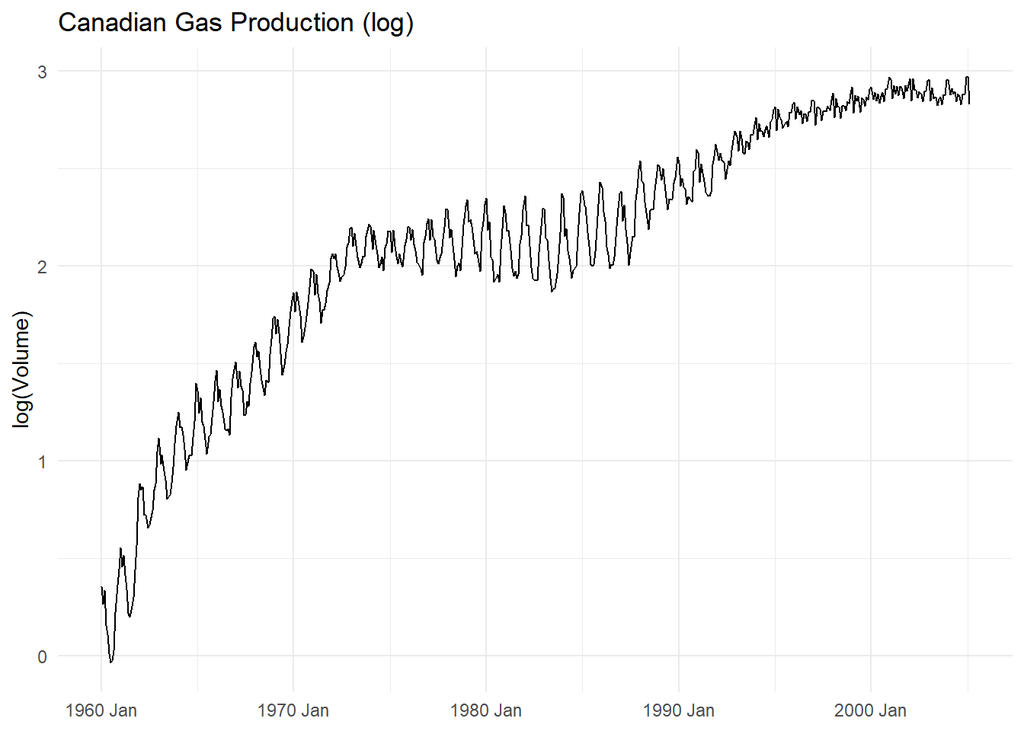

```r
can_gas <- can_gas |>
  mutate(log_volume = log(Volume))

can_gas |>
  autoplot(log_volume) +
  labs(title = "Canadian Gas Production (log)", x = NULL, y = "log(Volume)") +
  theme_minimal()
```

After the log transformation, the trend becomes different. It is steep in the 60s-70s then flattens out instead of having this appearance of constantly accelerating growth. The log transformation also shrinks seasonal swings over time. I think logs are reasonable since they make the trends easier to work with and in terms of percentages but it isn’t a one size fits all solution.

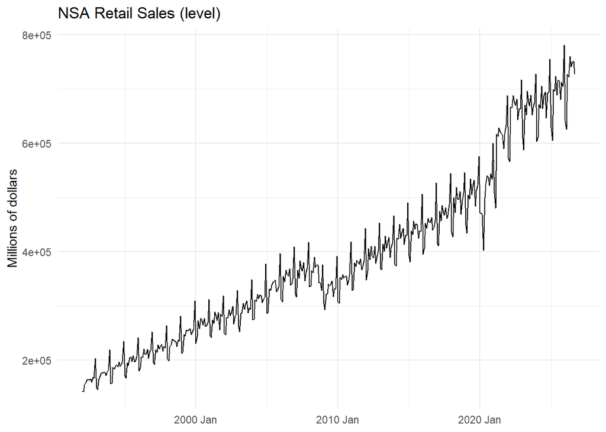

```r
retail_nsa <- retail_ts |>
  filter(series_id == "RSAFSNA") |>
  mutate(log_sales = log(sales))

retail_nsa |>
  autoplot(sales) +
  labs(title = "NSA Retail Sales (level)", x = NULL, y = "Millions of dollars") +
  theme_minimal()
```

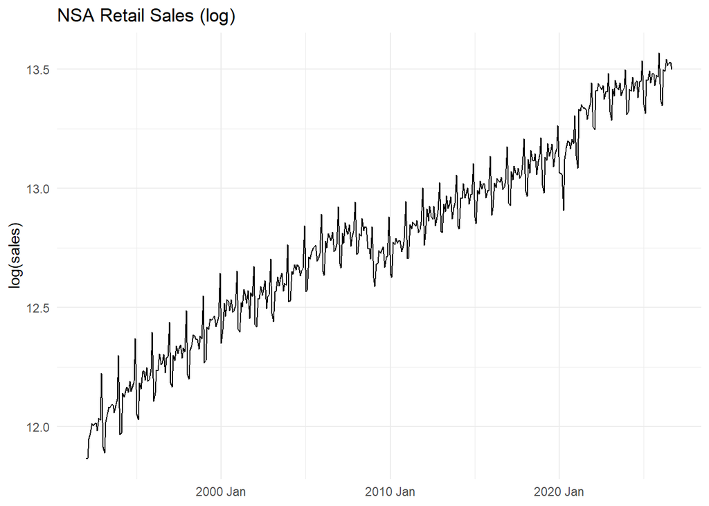

```r
retail_nsa |>
  autoplot(log_sales) +
  labs(title = "NSA Retail Sales (log)", x = NULL, y = "log(sales)") +
  theme_minimal()
```

The case for logs is a lot stronger for retail sales because in levels the seasonal holiday spike grows with the series and this can be captured in percentage change with logs.

### 3.2 Growth rates

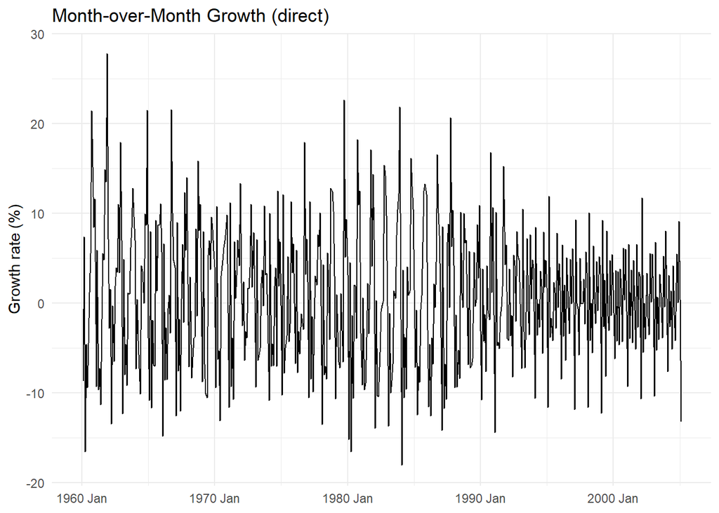

```r
can_gas <- can_gas |>
  mutate(
    growth_direct  = 100 * difference(Volume) / lag(Volume),
    growth_logdiff = 100 * difference(log_volume),
    growth_gap     = abs(growth_direct - growth_logdiff)
  )

can_gas |>
  autoplot(growth_direct) +
  labs(title = "Month-over-Month Growth (direct)", x = NULL, y = "Growth rate (%)") +
  theme_minimal()
```

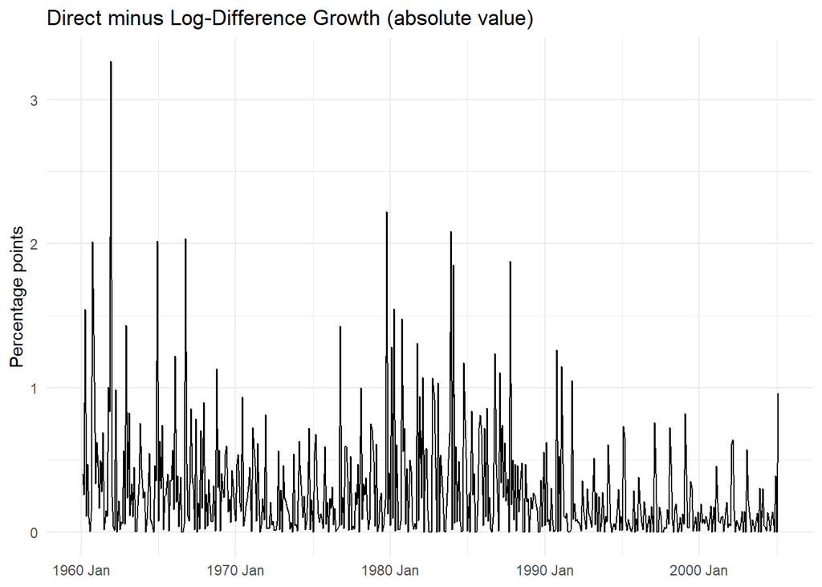

```r
can_gas |>
  autoplot(growth_gap) +
  labs(title = "Direct minus Log-Difference Growth (absolute value)",
       x = NULL, y = "Percentage points") +
  theme_minimal()
```

The approximation is good. The gap is small next to the growth rates since changes aren’t so big as to make log approximation inaccurate.

### 3.3 SA vs. NSA growth rates

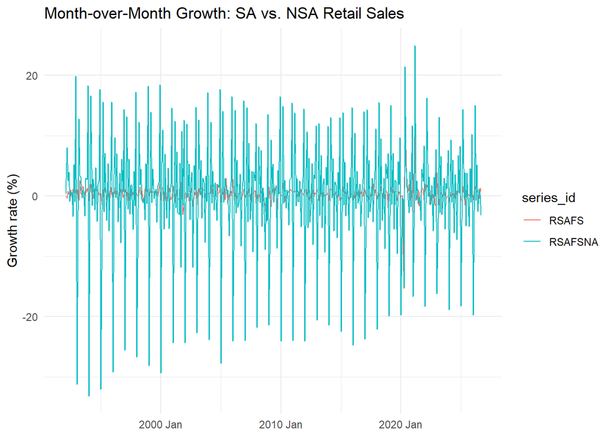

```r
retail_ts <- retail_ts |>
  group_by_key() |>
  mutate(growth_mom = 100 * difference(log(sales))) |>
  ungroup()

retail_ts |>
  autoplot(growth_mom) +
  labs(
    title = "Month-over-Month Growth: SA vs. NSA Retail Sales",
    x = NULL, y = "Growth rate (%)", color = NULL
  ) +
  theme_minimal()
```

The NSA is far noisier since it is not seasonally adjusted and the NSA growth rate is dominated by the seasonal noise. In this case the noise completed overwhelms the signal and the seasonally adjusted series filters that noise out and is able to get the signal.

## Seasonality

### 4.1 Season plots

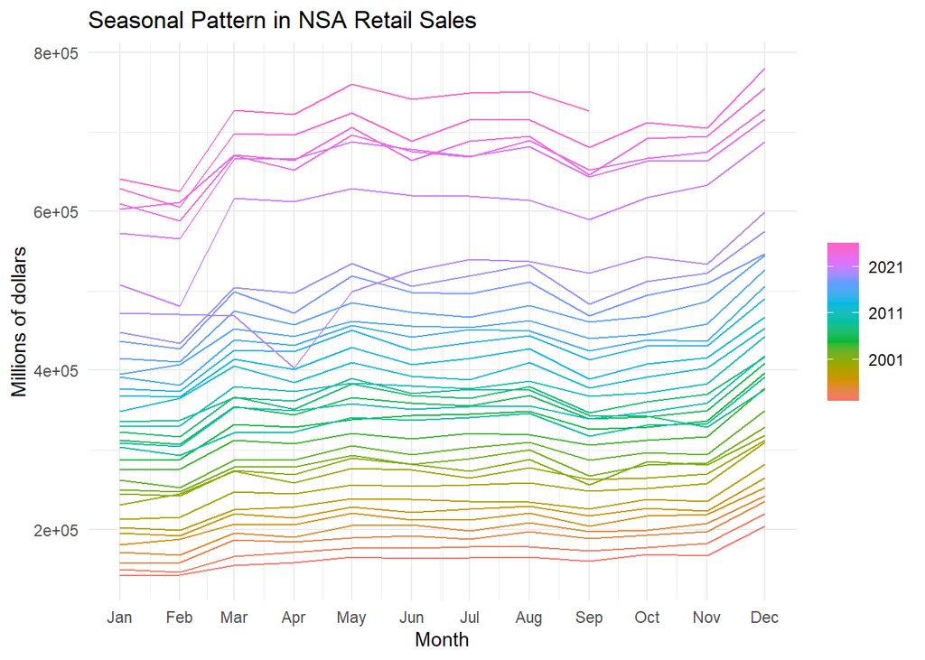

```r
retail_ts |>
  filter(series_id == "RSAFSNA") |>
  gg_season(sales) +
  labs(title = "Seasonal Pattern in NSA Retail Sales", y = "Millions of dollars") +
  theme_minimal()
```

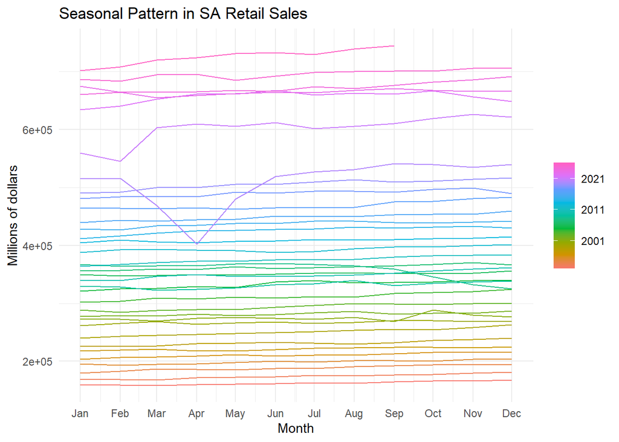

```r
retail_ts |>
  filter(series_id == "RSAFS") |>
  gg_season(sales) +
  labs(title = "Seasonal Pattern in SA Retail Sales", y = "Millions of dollars") +
  theme_minimal()
```

The NSA lines have the same shape which is low in Jan and Feb and rising to a spike in December. In the SA plot the lines are practically flat within each year taking out this yearly recurring pattern.

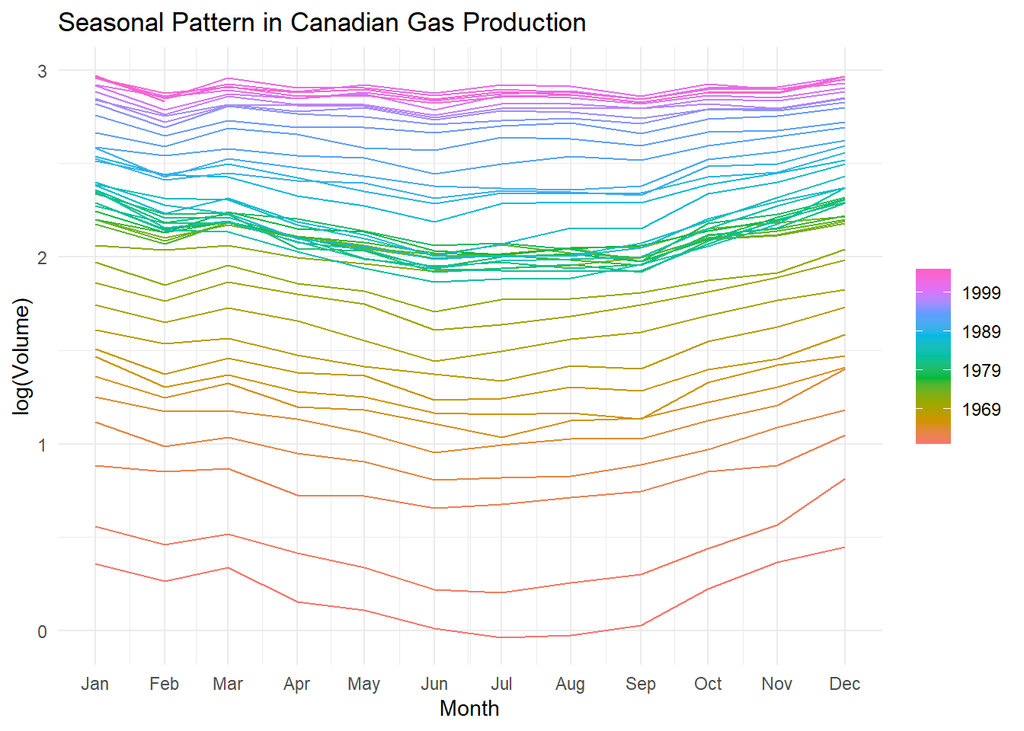

```r
can_gas |>
  gg_season(log_volume) +
  labs(title = "Seasonal Pattern in Canadian Gas Production", y = "log(Volume)") +
  theme_minimal()
```

High and low months since gas is used for heating in the winter and has lowest need in the summer when it is hot.

### 4.2 Subseries plot

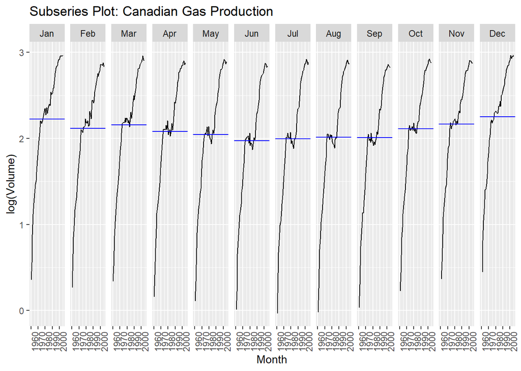

```r
can_gas |>
  gg_subseries(log_volume) +
  labs(title = "Subseries Plot: Canadian Gas Production", y = "log(Volume)")
```

### 4.3 X-13ARIMA-SEATS

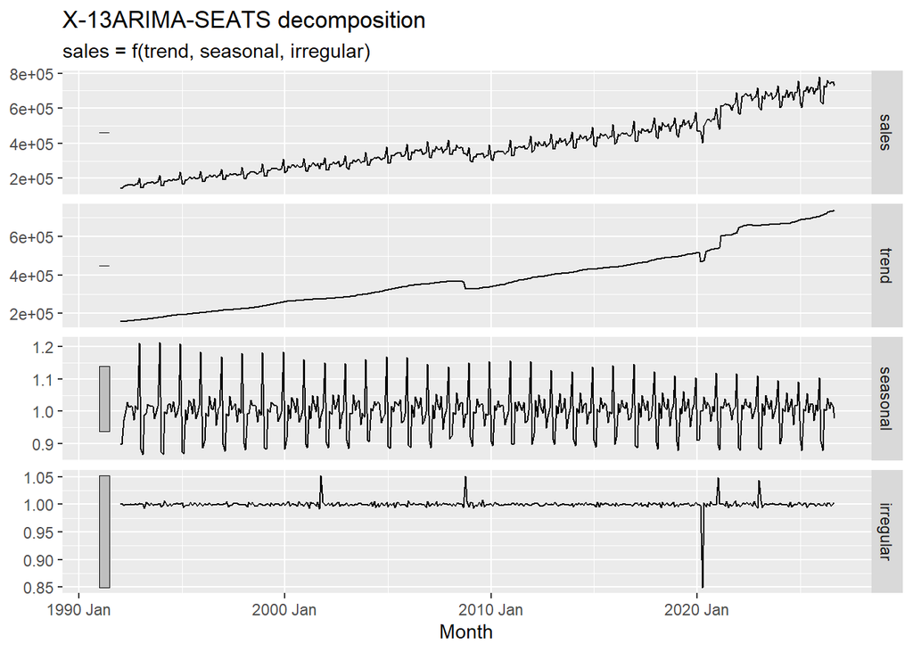

```r
retail_nsa_x13 <- retail_ts |>
  filter(series_id == "RSAFSNA") |>
  model(x13 = X_13ARIMA_SEATS(sales)) |>
  components()

retail_nsa_x13 |> autoplot()
```

The seasonal factor is definitely highest in Dec which is about 15% above the trend and the lowest months are Jan/Feb. The swing shrinks over time which makes sense since holiday shopping happens in the months before Dec more often due to online shopping.

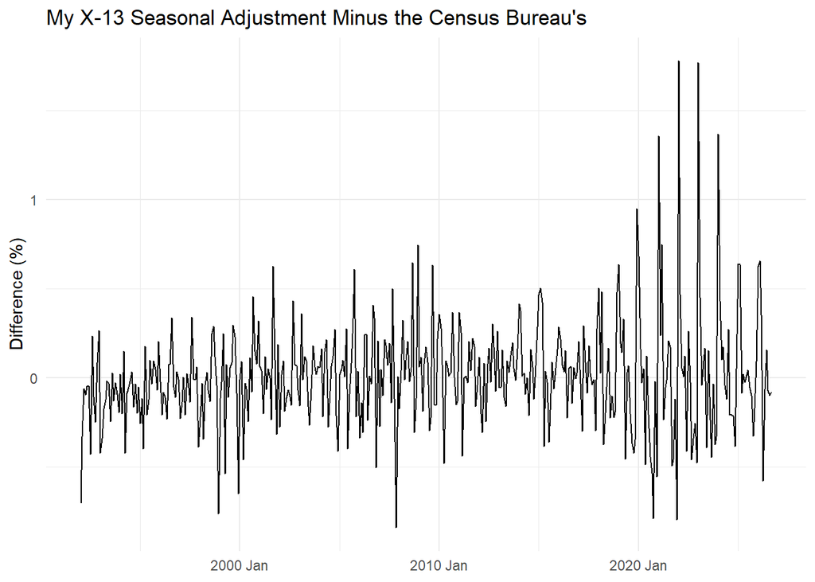

```r
sa_compare <- retail_nsa_x13 |>
  as_tibble() |>
  select(Month, mine = season_adjust) |>
  left_join(
    retail_ts |>
      filter(series_id == "RSAFS") |>
      as_tibble() |>
      transmute(Month, census = sales),
    by = "Month"
  ) |>
  mutate(pct_diff = 100 * (log(mine) - log(census)))

sa_compare |>
  ggplot(aes(x = Month, y = pct_diff)) +
  geom_line() +
  labs(
    title = "My X-13 Seasonal Adjustment Minus the Census Bureau's",
    x = NULL, y = "Difference (%)"
  ) +
  theme_minimal()
```

My adjustment is pretty close to the official one. The average abs difference is only around 0.2%. The largest differences are after 2019 which makes sense because COVID is a forecasting nightmare.

### 4.4 Linear trend + seasonal dummies

```r
can_gas_fit <- can_gas |>
  model(TSLM(log_volume ~ trend() + season()))

report(can_gas_fit)
```

```
Series: log_volume
Model: TSLM

Residuals:
      Min        1Q    Median        3Q       Max
-0.985307 -0.096451 -0.004525  0.131639  0.470564

Coefficients:
                 Estimate Std. Error t value Pr(>|t|)
(Intercept)     1.150e+00  4.142e-02  27.761  < 2e-16 ***
trend()         3.973e-03  6.886e-05  57.692  < 2e-16 ***
season()year2  -1.121e-01  5.229e-02  -2.144  0.03245 *
season()year3  -5.238e-02  5.258e-02  -0.996  0.31963
season()year4  -1.334e-01  5.258e-02  -2.537  0.01146 *
season()year5  -1.738e-01  5.258e-02  -3.305  0.00101 **
season()year6  -2.512e-01  5.258e-02  -4.777 2.30e-06 ***
season()year7  -2.300e-01  5.258e-02  -4.374 1.47e-05 ***
season()year8  -2.193e-01  5.258e-02  -4.170 3.56e-05 ***
season()year9  -2.274e-01  5.258e-02  -4.325 1.83e-05 ***
season()year10 -1.253e-01  5.258e-02  -2.383  0.01753 *
season()year11 -7.781e-02  5.258e-02  -1.480  0.13956
season()year12  7.202e-03  5.258e-02   0.137  0.89111
---
Signif. codes:  0 '***' 0.001 '**' 0.01 '*' 0.05 '.' 0.1 ' ' 1

Residual standard error: 0.2508 on 529 degrees of freedom
Multiple R-squared: 0.8652, Adjusted R-squared: 0.8622
F-statistic:   283 on 12 and 529 DF, p-value: < 2.22e-16
```

```r
can_gas_fit |>
  tidy() |>
  select(term, estimate, std.error, statistic, p.value) |>
  knitr::kable(digits = 3)
```

| term | estimate | std.error | statistic | p.value |
| --- | --- | --- | --- | --- |
| (Intercept) | 1.150 | 0.041 | 27.761 | 0.000 |
| trend() | 0.004 | 0.000 | 57.692 | 0.000 |
| season()year2 | -0.112 | 0.052 | -2.144 | 0.032 |
| season()year3 | -0.052 | 0.053 | -0.996 | 0.320 |
| season()year4 | -0.133 | 0.053 | -2.537 | 0.011 |
| season()year5 | -0.174 | 0.053 | -3.305 | 0.001 |
| season()year6 | -0.251 | 0.053 | -4.777 | 0.000 |
| season()year7 | -0.230 | 0.053 | -4.374 | 0.000 |
| season()year8 | -0.219 | 0.053 | -4.170 | 0.000 |
| season()year9 | -0.227 | 0.053 | -4.325 | 0.000 |
| season()year10 | -0.125 | 0.053 | -2.383 | 0.018 |
| season()year11 | -0.078 | 0.053 | -1.480 | 0.140 |
| season()year12 | 0.007 | 0.053 | 0.137 | 0.891 |

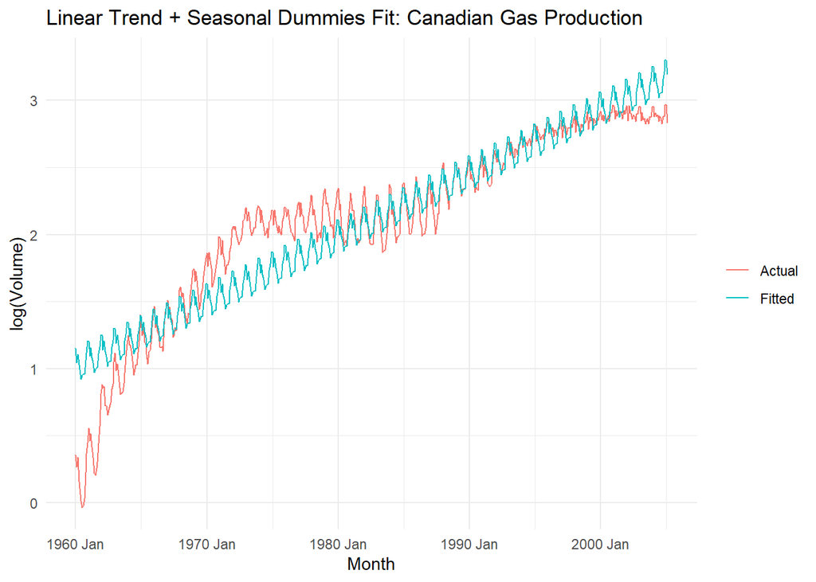

```r
can_gas_fit |>
  augment() |>
  ggplot(aes(x = Month)) +
  geom_line(aes(y = log_volume, color = "Actual")) +
  geom_line(aes(y = .fitted, color = "Fitted")) +
  labs(title = "Linear Trend + Seasonal Dummies Fit: Canadian Gas Production",
       y = "log(Volume)", color = NULL) +
  theme_minimal()
```

The fitted line is capturing the overall direction and timing but is missing the shape pretty badly as we saw in the log transformations.

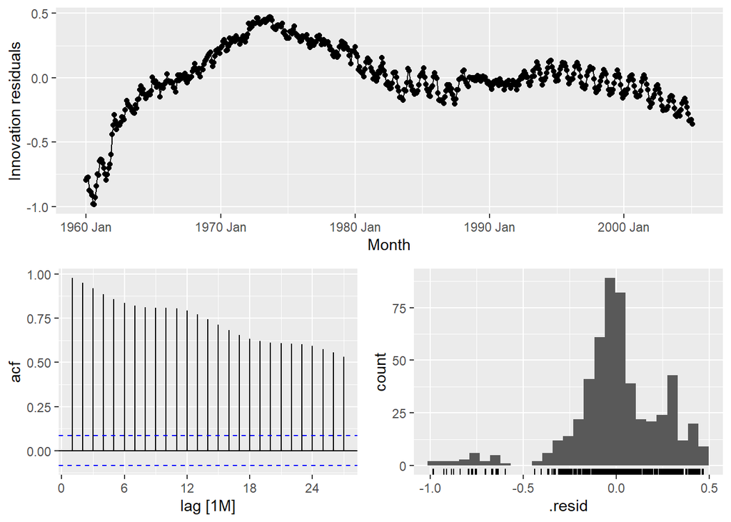

```r
can_gas_fit |> gg_tsresiduals()
```

```r
can_gas_fit |>
  augment() |>
  features(.innov, ljung_box, lag = 24)
```

```
# A tibble: 1 × 3
  .model                                lb_stat lb_pvalue
  <chr>                                   <dbl>     <dbl>
1 TSLM(log_volume ~ trend() + season())   7774.         0
```

The residuals are definitely not white noise since there is a visible pattern or structure to them. Also the Ljung-Box stat has a p-value of essentially zero so we reject that the residuals are white noise.

## Forecast Evaluation

### 5.1 Expanding-window TS-CV

```r
gas_cv_fc <- can_gas |>
  select(Month, Volume) |>
  stretch_tsibble(.init = 240, .step = 1) |>
  model(snaive = SNAIVE(Volume),
        tslm   = TSLM(log(Volume) ~ trend() + season())) |>
  forecast(h = 1)

gas_cv_fc |>
  accuracy(can_gas, measures = list(MAE = MAE, RMSE = RMSE)) |>
  knitr::kable(digits = 3)
```

| .model | .type | MAE | RMSE |
| --- | --- | --- | --- |
| snaive | Test | 0.562 | 0.702 |
| tslm | Test | 4.009 | 4.362 |

**5.1a.** The first evaluated forecast is for **January 1980**, after training on 1960–1979. The last is for **February 2005**: the March 2005 forecast has no actual to compare against. That gives 302 one-step-ahead forecasts.

| Model | MAE | RMSE |
| --- | --- | --- |
| SNAIVE | 0.562 | 0.702 |
| TSLM | 4.01 | 4.36 |

The seasonal naive model is far more accurate, with errors roughly 6–7 times smaller. MAE and RMSE agree.

### 5.2 Diebold–Mariano test

```r
errs <- gas_cv_fc |>
  as_tibble() |>
  left_join(as_tibble(can_gas) |> select(Month, actual = Volume),
            by = "Month") |>
  mutate(e = actual - .mean) |>
  select(Month, .model, e) |>
  pivot_wider(names_from = .model, values_from = e) |>
  na.omit()

forecast::dm.test(errs$snaive, errs$tslm, h = 1, power = 1)
```

```
    Diebold-Mariano Test

data:  errs$snaiveerrs$tslm
DM = -31.278, Forecast horizon = 1, Loss function power = 1, p-value <
2.2e-16
alternative hypothesis: two.sided
```

**5.2a.** DM = −31.28, p-value < 2.2e-16. We strongly reject the null that the two models forecast equally well. The negative statistic means the seasonal naive model has the smaller absolute errors, so it is significantly more accurate than the trend + seasonal dummies model.

### 5.3 Rolling window

```r
gas_cv_fc_roll <- can_gas |>
  select(Month, Volume) |>
  slide_tsibble(.size = 240, .step = 1) |>
  model(snaive = SNAIVE(Volume),
        tslm   = TSLM(log(Volume) ~ trend() + season())) |>
  forecast(h = 1)

gas_cv_fc_roll |>
  accuracy(can_gas, measures = list(MAE = MAE, RMSE = RMSE)) |>
  knitr::kable(digits = 3)
```

| .model | .type | MAE | RMSE |
| --- | --- | --- | --- |
| snaive | Test | 0.562 | 0.702 |
| tslm | Test | 2.095 | 2.425 |

**5.3a.**

| Model | MAE | RMSE |
| --- | --- | --- |
| SNAIVE | 0.562 | 0.702 |
| TSLM | 2.09 | 2.42 |

SNAIVE is unchanged, because it only ever uses the value from 12 months earlier, so the window size doesn’t matter. TSLM improves a lot: its MAE drops by about half, from 4.01 to 2.09. As we saw in 4.4b, the true trend is curved: fast growth early, then flattening. With an expanding window, the fitted line is always pulled up by the steep 1960s–70s growth and overshoots the slower later years. A rolling 20-year window drops those old years, so the fitted slope adapts to recent growth. TSLM is still well behind SNAIVE, though.

## Reflection

The residuals from the trend + seasonal dummies model still contained a lot of structure. They showed a slow wave over time, and their autocorrelations were close to 1 and died out very slowly. That means this month’s error is a very good predictor of next month’s. The model was missing two things: a trend that can bend or shift over time instead of a single straight line, and seasonality whose size can change. The forecast evaluation tells the same story. The seasonal naive model, which uses only last year’s value and so adapts automatically to wherever the series is now, beat the regression easily, and the regression improved when a rolling window let it adapt. A better model would let recent observations matter more. For example, it could model the residuals’ persistence directly (as an ARIMA-type model does) or let the level, trend, and seasonal pattern evolve over time (as exponential smoothing does), rather than fixing them for the whole sample.